# Solar production modelling: solution

1. Load data and separate it into training and testing set:

```r
library(mgcViz);
load(paste0(goodLocation, "/data/solar_prod.rda")) # change this

set.seed(515)
iTest <- sample(1:nrow(solar_prod), 2000)
DataTEST <- solar_prod[iTest, ]
DataTRAIN <- solar_prod[-iTest, ]
```

2. Fit median quantile GAM and look at tensor effect:

```r
fitQ <- qgamV(logprod ~ dow + te(Posan, Instant, bs = c("cc", "cc"), k = c(5, 5)),
                        data=DataTRAIN, qu = 0.5)
```

```
## Estimating learning rate. Each dot corresponds to a loss evaluation.
## qu = 0.5.........done
```

```r
plotRGL( sm(fitQ, 1), residuals = TRUE )
```

[interactive chart not shown]

The `rgl` plot shows a clear pattern in the residuals sign along `Instant`.

3. We can have a look at corresponding pinball loss using `l_gridCheck2D`:

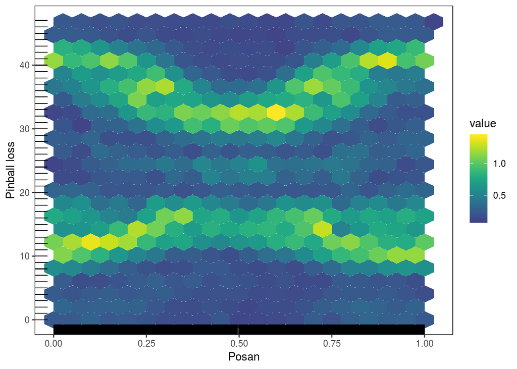

```r
pinball <- function(y, mu, qu){ # mu is fitted quantile, qu is quantile of interest
  tau <- 1 - qu
  d <- y - mu
  l <- d * 0
  l[d < 0] <- - tau*d[d<0]
  l[d > 0] <- - (tau-1)*d[d>0]
  return( l )
}

check2D(fitQ, "Posan", "Instant", type = "y",
        trans = function(x, ...) pinball(x, fitQ$fitted.values, qu = 0.5)) +
        l_gridCheck2D(mean, stand = F) +
  l_rug() + ylab("Pinball loss")
```

4. We increase the number of basis functions along `Instant` and refit:

```r
fitQ2 <- qgamV(logprod ~ dow + te(Posan, Instant, bs = c("cc", "cc"), k = c(5, 15)),
                data=DataTRAIN, qu = 0.5)
```

```
## Estimating learning rate. Each dot corresponds to a loss evaluation.
## qu = 0.5........done
```

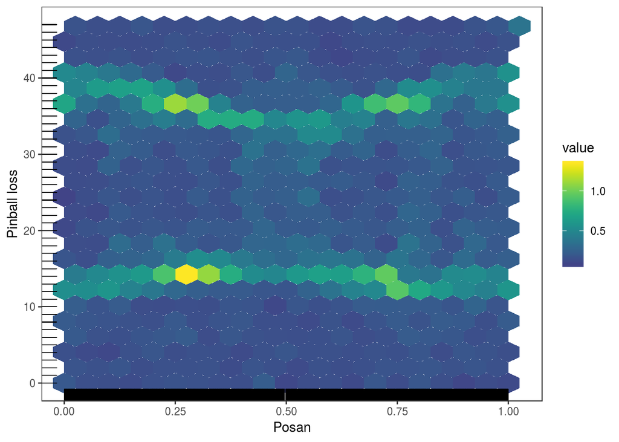

```r
check2D(fitQ2, "Posan", "Instant", type = "y",
        trans = function(x, ...) pinball(x, fitQ2$fitted.values, qu = 0.5)) +
        l_gridCheck2D(mean, stand = F) +
  l_rug() + ylab("Pinball loss")
```

```r
AIC(fitQ, fitQ2)
```

```
##             df      AIC
## fitQ  21.86426 53366.83
## fitQ2 61.67312 33275.63
```

Pinball loss seems more uniform across `Posan` and `Instant`, and AIC much improved! We can perform a further check using `l_gridQCheck2D`:

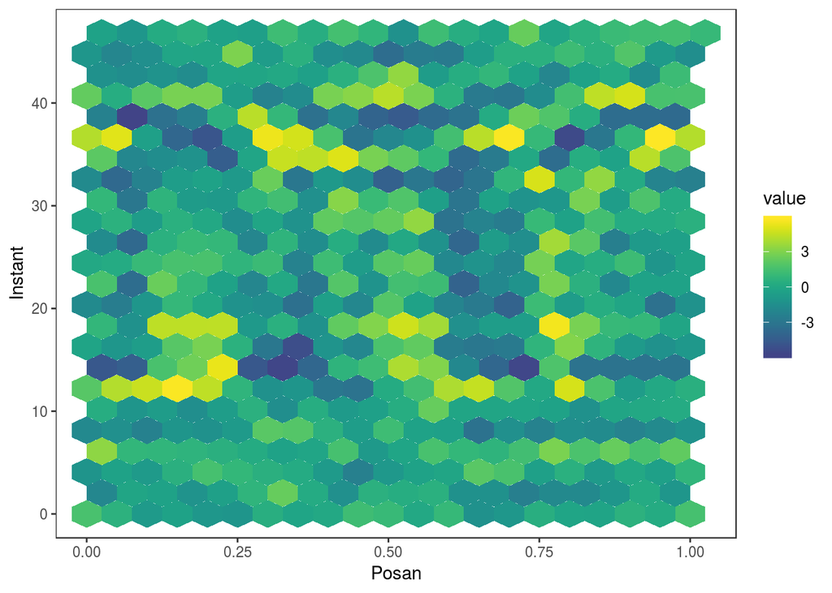

```r
check2D(fitQ2, "Posan", "Instant") + l_gridQCheck2D()
```

`l_gridQCheck2D` does not show any pattern, hence we suspect that the pattern still visible in the pinball loss plot above might be due to the variance of the residuals being not constant across `Posan` and `Instant`.

5. Fit multiple quantiles:

```r
qus = seq(0.1, 0.9, length.out = 5)
fitMQ <- mqgamV(logprod ~ dow + te(Posan, Instant, bs = c("cc", "cc"), k = c(5, 15)),
                 data=DataTRAIN, qus)
```

```
## Estimating learning rate. Each dot corresponds to a loss evaluation.
## qu = 0.5........done
## qu = 0.3........done
## qu = 0.7........done
## qu = 0.1..........done
## qu = 0.9................done
```

Use test set on median model, and plot the pinball loss vs `Instant` and `Posan`:

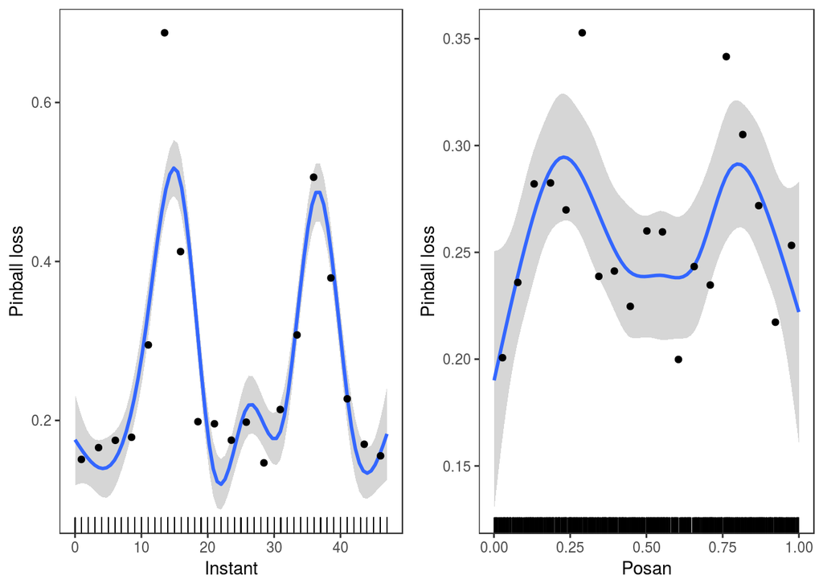

```r
fit50 <- getViz(fitMQ[[3]], newdata = DataTEST)

pl <- check1D(fit50, list("Instant", "Posan"), type = "y",
              trans = function(x, ...) pinball(x, predict(fit50, newdata = DataTEST), qu = 0.5)) +
  geom_smooth() +
  l_gridCheck1D(gridFun = mean, level = 0) +
  l_rug() + ylab("Pinball loss")

print(pl, pages = 1)
```

The plot across `Instant` shows large losses near to sunrise and sunset, possibly because solar production surges or collapses very suddenly at those times:

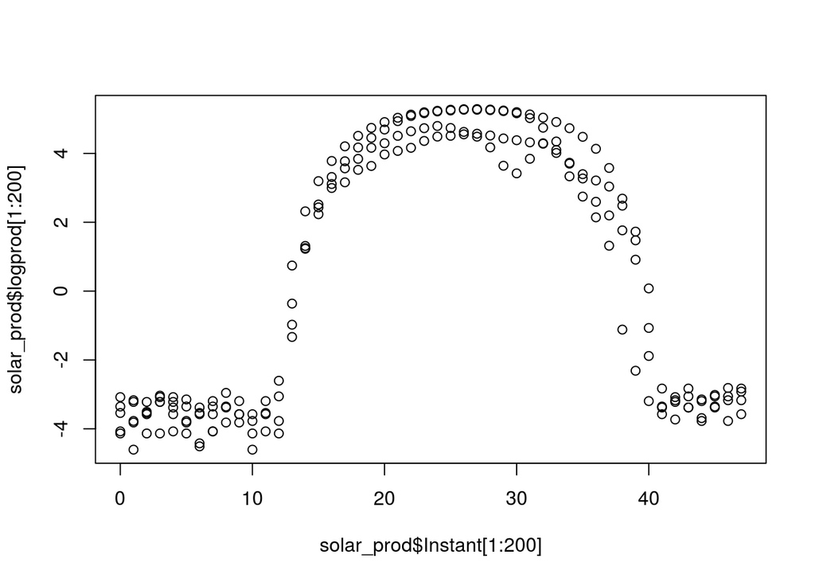

```r
plot(solar_prod$Instant[1:200], solar_prod$logprod[1:200])
```

Similarly, the second plot shows that higher losses as `Posan`$\approx$ 0.25 and 0.75, probably because the hours of daylight at changes at the fastest rather during those periods.

6. Fit Gaulss GAM and plot tensor effect on variance:

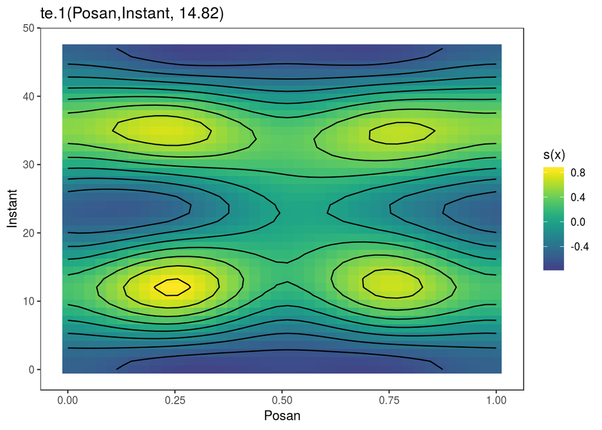

```r
fitLSS <- gamV(list(logprod ~ dow + te(Posan, Instant, bs= c("cc", "cc"), k = c(5, 15)),
                            ~ dow + te(Posan, Instant, bs= c("cc", "cc"), k = c(5, 5))),
               family = gaulss,
               data=DataTRAIN)

plot(fitLSS, select = 2)
```

There are four spikes in the variance effect. These are probably attributable to the fact that the production surge (collapse) at sunrise (sunset) is difficult to capture with a non-adaptive smooth effect. Futher the time of day at which sunrise happens changes at the fastest rate around the equinoxes, hence it makes sense having higher variance around `Posan = 0.25` and `Posan = 0.75`.

7. We fit a standard Gaussian GAM:

```r
fitGAUS <- gamV(logprod ~ te(Posan, Instant, bs= c("cc", "cc"), k = c(5, 15)),
                data = DataTRAIN)
```

Then we check the pinball losses along one of the two covariates, for each quantile and model:

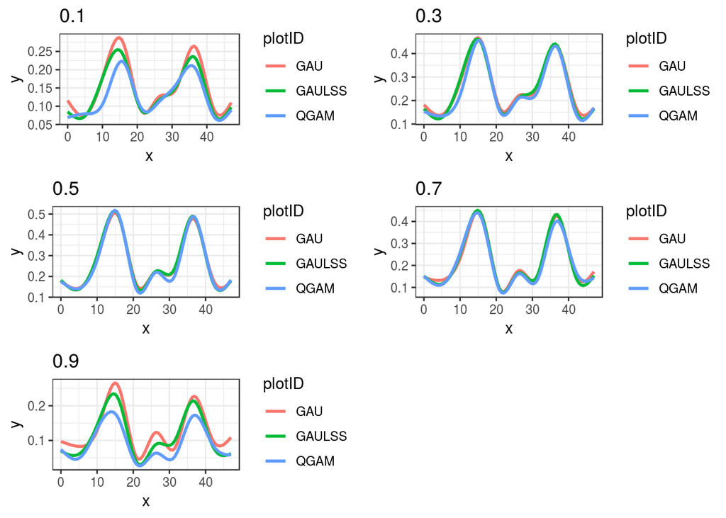

```r
compareMod <- function(QGAM, GAUS, GAULSS, dat, variab){

  nq <- length(QGAM)
  qus <- as.numeric(names(QGAM))

  pinQv <- lapply(1:nq, # QGAM
                  function(.ii){
                    tmp <- getViz(QGAM[[.ii]], newdata = dat)
                    check1D(tmp, variab, type = "y",
                            trans = function(x, ...)
                              pinball(x, predict(tmp, newdata = dat), qu = qus[.ii]))
                  })

  pinGAUSv <- lapply(1:nq, # GAUSSIAN GAM
                     function(.ii){
                       tmp <- getViz(GAUS, newdata = dat)
                       check1D(tmp, variab, type = "y",
                               trans = function(x, ...)
                                 pinball(x,
                                         qnorm(qus[.ii], predict(tmp, newdata = dat), sqrt(fitGAUS$sig2)),
                                         qu = qus[.ii]))
                     })

  pinLSSv <- lapply(1:nq, # GAULSS
                    function(.ii){
                      tmp <- getViz(GAULSS, newdata = dat)
                      check1D(tmp, variab, type = "y",
                              trans = function(x, ...){
                                .pred <- predict(tmp, newdata = dat, type = "response")
                                pinball(x, qnorm(qus[.ii], .pred[ , 1], 1 / .pred[ , 2]), qu = qus[.ii])
                              })
                    })

  plts <- list()
  for(ind in 1:nq){
    plDat <- as.data.frame(rbind(pinQv[[ind]]$data$res, pinGAUSv[[ind]]$data$res, pinLSSv[[ind]]$data$res))
    plDat$plotID <- as.factor(rep(c("QGAM", "GAU", "GAULSS"), each = nrow(plDat)/3))

    plts[[ind]] <- ggplot(data = plDat,
                          mapping = aes(x = x, y = y, group = plotID, col = plotID, fill = plotID)) +
      geom_smooth(se = FALSE) + theme_bw() + ggtitle(qus[ind])
  }

  return(plts)

}

plts <- compareMod(QGAM = fitMQ, GAUS = fitGAUS, GAULSS = fitLSS, dat = DataTEST, variab = "Instant")
library(gridExtra)
grid.arrange(grobs = plts)
```